# NHL Playoffs

Vien Nguyen

18 Aug 2016

# 1 Introduction

The shot blocking data is obtained from the [NHL stats site](http://www.nhl.com/stats/). We loop through all seasons from 2006-present and pull the regular season cumulative shot blocks for teams that played in the playoffs in each year.

## 1.1 Set working directory and load required packages

```r
setwd("/Users/tvnguyen/R_expert/hockey/Hockey")
library(dplyr)
```

```r
library(ggplot2)
library(plyr)
```

## 1.2 Import datasets

```r
df = read.csv('data-v2.csv', header = TRUE, sep = ',')
summary(df)
```

```
##      season              team      numGamesPlayoffs numBlocksPlayoffs
##  Min.   :20062007   Min.   : 1.0   Min.   : 4.00    Min.   : 36.0
##  1st Qu.:20082009   1st Qu.: 6.0   1st Qu.: 6.00    1st Qu.: 86.5
##  Median :20102011   Median :16.0   Median : 9.00    Median :141.0
##  Mean   :20106791   Mean   :15.1   Mean   :10.69    Mean   :165.4
##  3rd Qu.:20132014   3rd Qu.:23.0   3rd Qu.:13.50    3rd Qu.:223.5
##  Max.   :20152016   Max.   :30.0   Max.   :26.00    Max.   :419.0
##  numGamesRegular numBlocksRegular
##  Min.   :48.00   Min.   : 511.0
##  1st Qu.:82.00   1st Qu.: 965.5
##  Median :82.00   Median :1071.0
##  Mean   :78.58   Mean   :1059.0
##  3rd Qu.:82.00   3rd Qu.:1209.5
##  Max.   :82.00   Max.   :1557.0
```

```r
head(df)
```

```
##     season team numGamesPlayoffs numBlocksPlayoffs numGamesRegular
## 1 20062007    1               11               172              82
## 2 20062007    2                5                91              82
## 3 20062007    3               10               159              82
## 4 20062007    5                5                88              82
## 5 20062007    7               16               290              82
## 6 20062007    9               20               310              82
##   numBlocksRegular
## 1             1127
## 2             1307
## 3             1386
## 4             1238
## 5             1248
## 6             1242
```

# 2 Data pre-processing

## 2.1 Data normalizing

We’ll need to normalize this data so we can investigate across the different number of games in the regular season and the playoffs, and compare between the various teams that play a different number of games in the playoffs. To do this, we’ll take the total of all the shot blocks in the regular season or playoffs and divide by the number of games in which those blocks were accumulated to get shot blocks per game.

```r
df$blkPerGmRegular <- df$numBlocksRegular / df$numGamesRegular
df$blkPerGmPlayoff <- df$numBlocksPlayoffs / df$numGamesPlayoffs
df$blkDiff <- df$blkPerGmPlayoff - df$blkPerGmRegular
```

## 2.2 Plot the regular season and playoff data separately

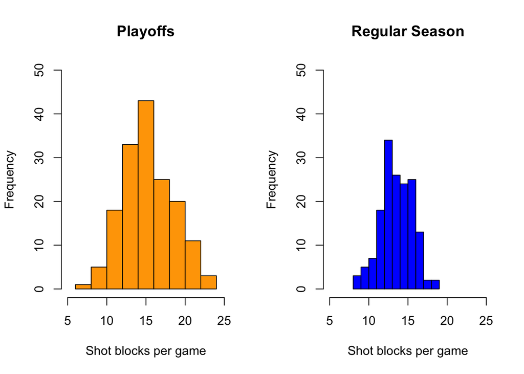

```r
par(mfrow=c(1,2))
hist(df$blkPerGmPlayoff, col = 'orange', main = 'Playoffs',
     xlab = 'Shot blocks per game',
     xlim = c(5, 25), ylim = c(0, 50))
hist(df$blkPerGmRegular, col = 'blue', main = 'Regular Season',
     xlab = 'Shot blocks per game',
     xlim = c(5, 25), ylim = c(0, 50))
```

## 2.3 Build combined data

```r
dat <- data.frame(cond = c(rep('Regular Season', length(df$blkPerGmRegular)),
                           rep('Playoffs', length(df$blkPerGmPlayoff))),
                  PerGbm = c(df$blkPerGmRegular, df$blkPerGmPlayoff))
```

# 3 Histogram and density plots

## 3.1 Basic histogram from the vector “PerGbm”. Each bin is .5 wide.

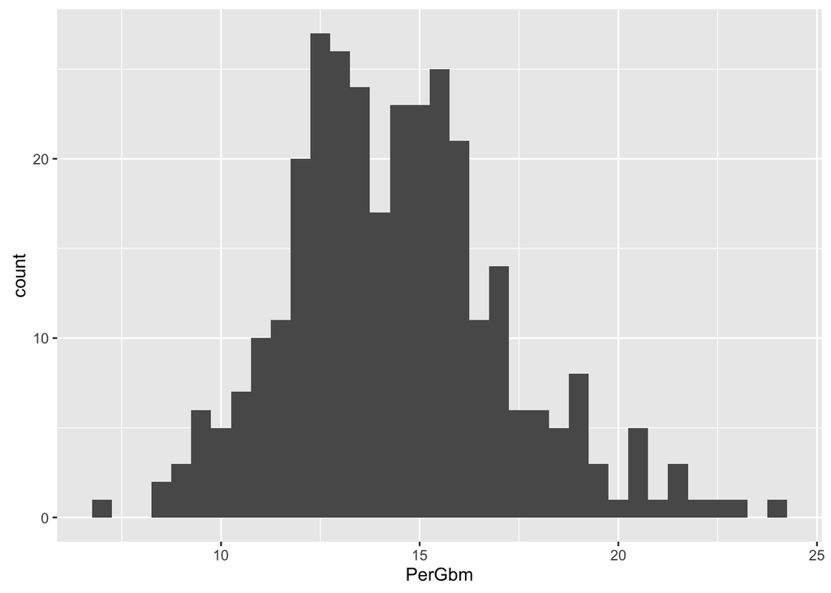

```r
ggplot(dat, aes(x=PerGbm)) + geom_histogram(binwidth=.5)
```

## 3.2 Draw with black outline, white fill

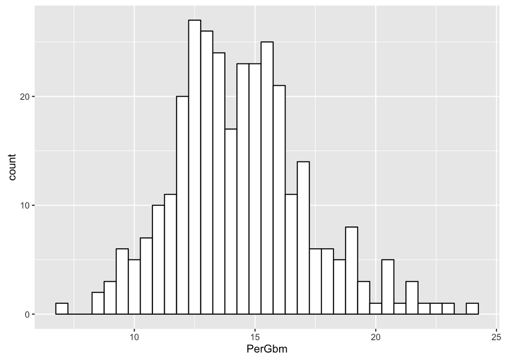

```r
ggplot(dat, aes(x=PerGbm)) +
  geom_histogram(binwidth=.5, colour="black", fill="white")
```

## 3.3 Density curve

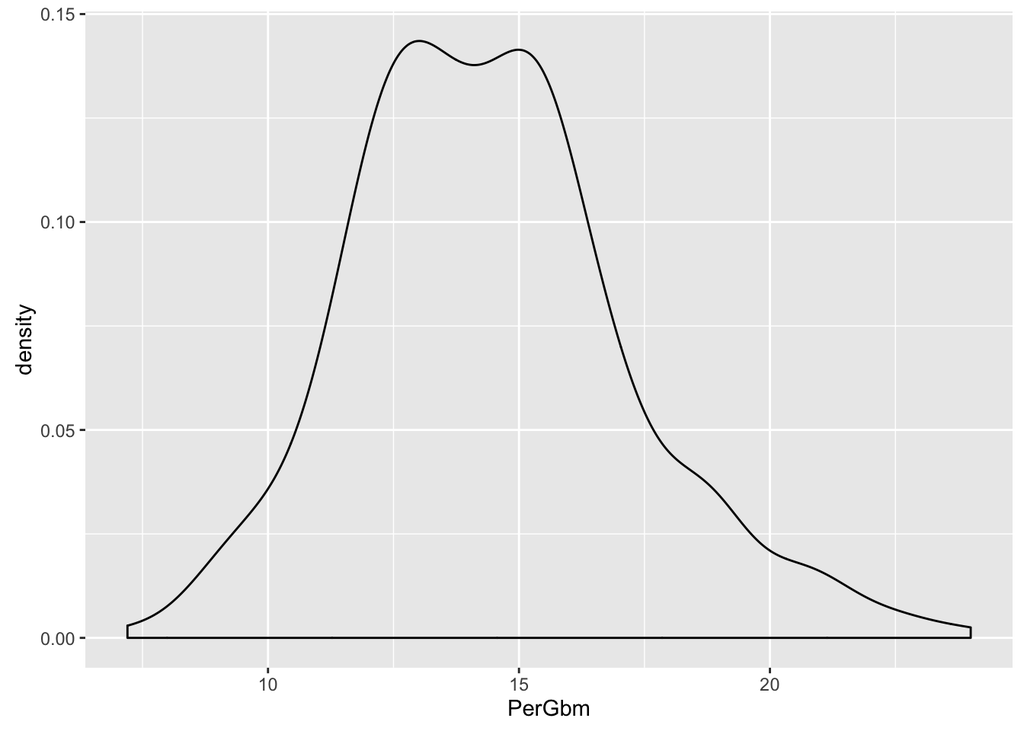

```r
ggplot(dat, aes(x=PerGbm)) + geom_density()
```

## 3.4 Histogram overlaid with kernel density curve

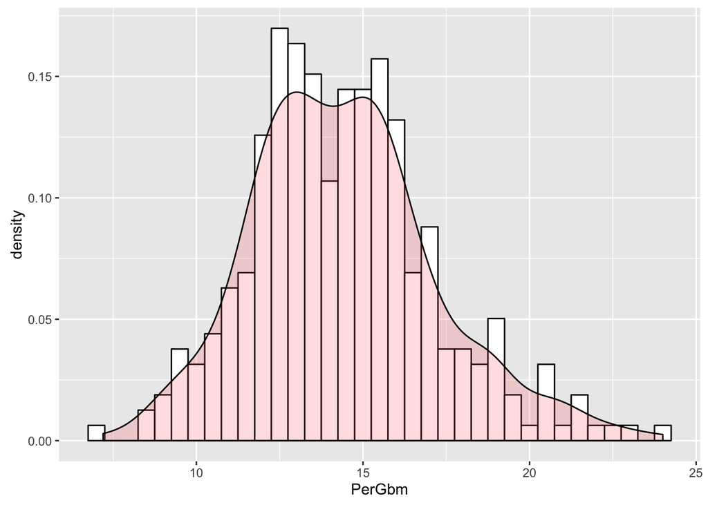

```r
ggplot(dat, aes(x=PerGbm)) +
  geom_histogram(aes(y=..density..),
                 binwidth=.5,
                 colour="black", fill="white") +
  geom_density(alpha=.2, fill="#FF6666")
```

## 3.5 Add a line for the mean for histogram and density plots

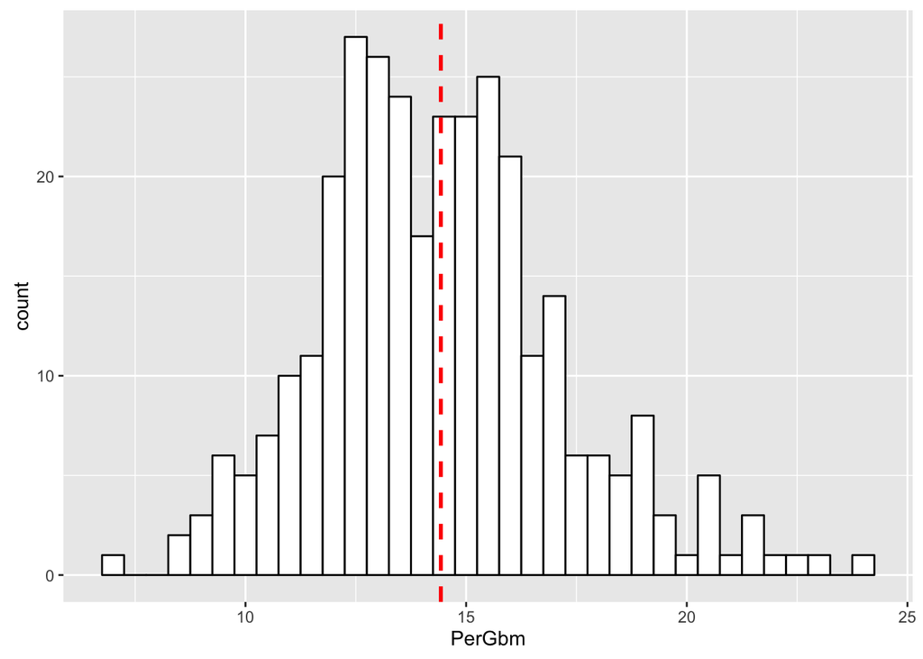

```r
ggplot(dat, aes(x=PerGbm)) +
  geom_histogram(binwidth=.5, colour="black", fill="white") +
  geom_vline(aes(xintercept=mean(PerGbm, na.rm=T)),   # Ignore NA values for mean
             color="red", linetype="dashed", size=1)
```

# 4 Histogram and density plots with multiple groups

## 4.1 Overlaid histograms

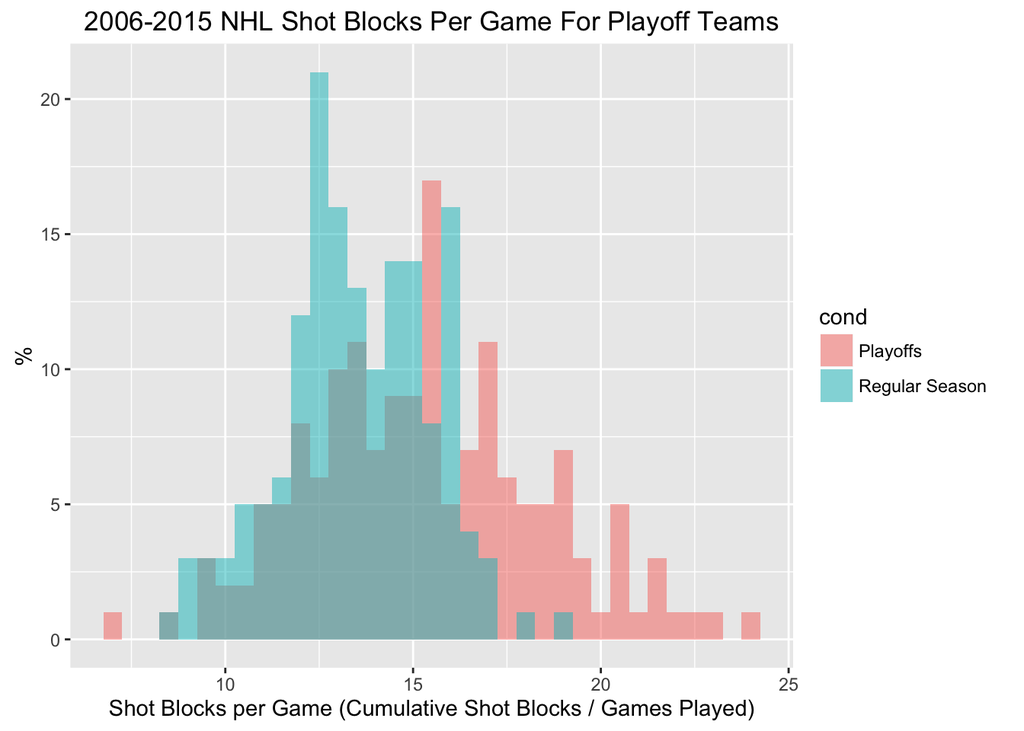

```r
ggplot(dat, aes(x=PerGbm, fill=cond)) +
  geom_histogram(binwidth=.5, alpha=.5, position="identity") +
  ggtitle('2006-2015 NHL Shot Blocks Per Game For Playoff Teams') +
  labs(x = 'Shot Blocks per Game (Cumulative Shot Blocks / Games Played)', y = '%')
```

## 4.2 Interleaved histograms

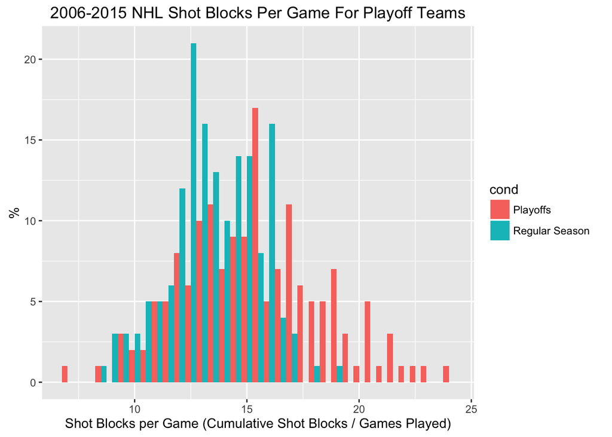

```r
ggplot(dat, aes(x=PerGbm, fill=cond)) +
  geom_histogram(binwidth=.5, position="dodge") +
  ggtitle('2006-2015 NHL Shot Blocks Per Game For Playoff Teams') +
  labs(x = 'Shot Blocks per Game (Cumulative Shot Blocks / Games Played)', y = '%')
```

## 4.3 Density plots

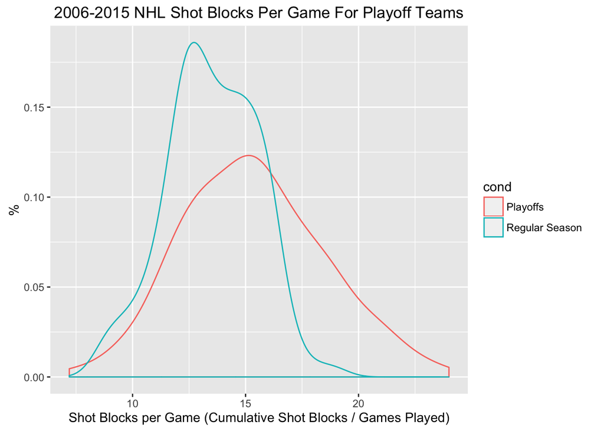

```r
ggplot(dat, aes(x=PerGbm, colour=cond)) + geom_density() +
  ggtitle('2006-2015 NHL Shot Blocks Per Game For Playoff Teams') +
  labs(x = 'Shot Blocks per Game (Cumulative Shot Blocks / Games Played)', y = '%')
```

## 4.4 Density plots with semi-transparent fill

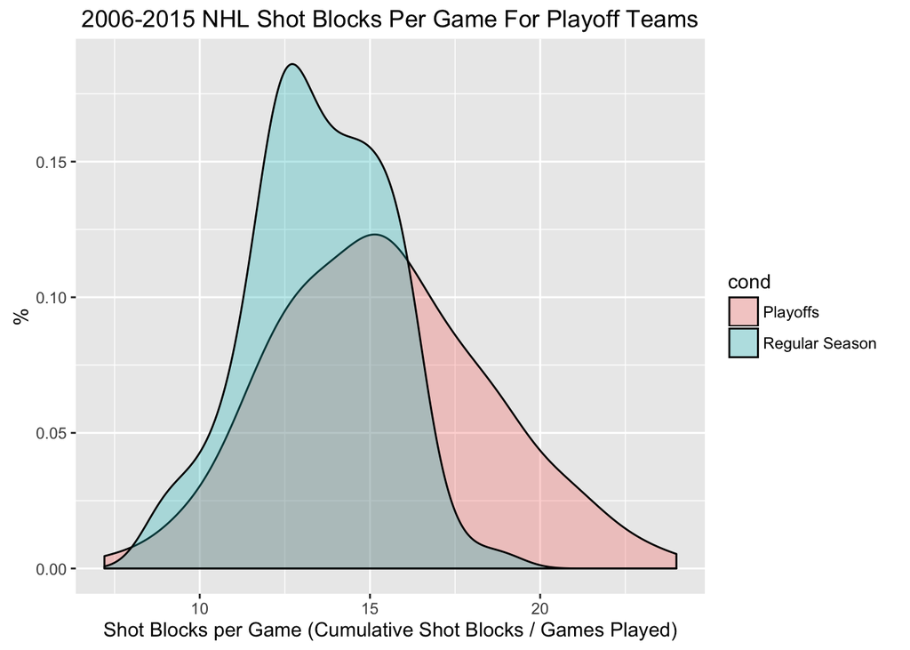

```r
ggplot(dat, aes(x=PerGbm, fill=cond)) + geom_density(alpha=.3) +
  ggtitle('2006-2015 NHL Shot Blocks Per Game For Playoff Teams') +
  labs(x = 'Shot Blocks per Game (Cumulative Shot Blocks / Games Played)', y = '%')
```

## 4.5 Plot the Playoff - Regular Difference

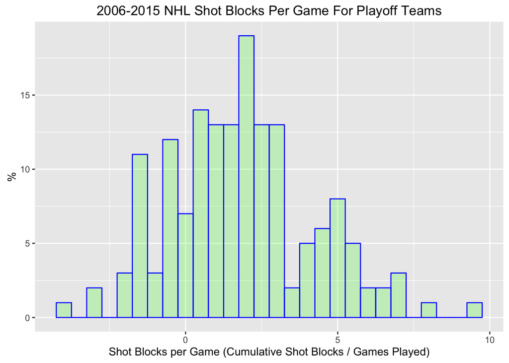

```r
ggplot(df, aes(x=blkDiff)) +
  geom_histogram(binwidth=.5, alpha=.2, col = 'blue', fill='green') +
  ggtitle('2006-2015 NHL Shot Blocks Per Game For Playoff Teams') +
  labs(x = 'Shot Blocks per Game (Cumulative Shot Blocks / Games Played)', y = '%')
```

# 5 Add lines for each mean requires first creating a separate data frame with the means.

## 5.1 Find the mean of each group

```r
cdat <- ddply(dat, "cond", summarise, PerGbm.mean=mean(PerGbm))
cdat
```

```
##             cond PerGbm.mean
## 1       Playoffs    15.34194
## 2 Regular Season    13.51219
```

## 5.2 Overlaid histograms with means

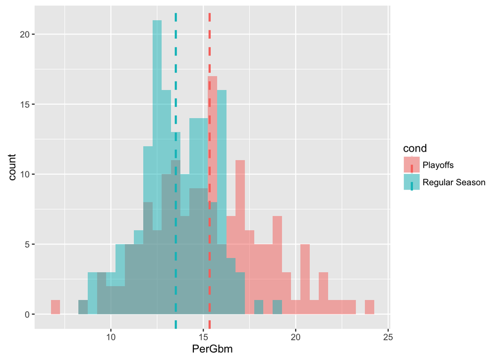

```r
ggplot(dat, aes(x=PerGbm, fill=cond)) +
  geom_histogram(binwidth=.5, alpha=.5, position="identity") +
  geom_vline(data=cdat, aes(xintercept=PerGbm.mean,  colour=cond),
             linetype="dashed", size=1)
```

## 5.3 Density plots with means

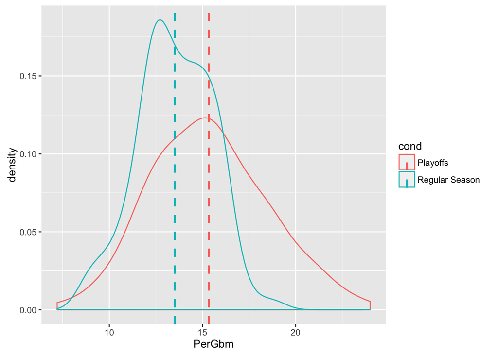

```r
ggplot(dat, aes(x=PerGbm, colour=cond)) +
  geom_density() +
  geom_vline(data=cdat, aes(xintercept=PerGbm.mean,  colour=cond),
             linetype="dashed", size=1)
```

## 5.4 Using facets

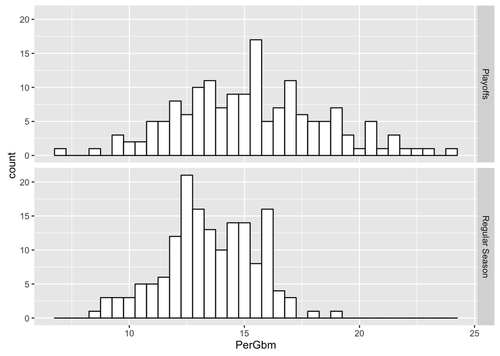

```r
ggplot(dat, aes(x=PerGbm)) + geom_histogram(binwidth=.5, colour="black", fill="white") +
  facet_grid(cond ~ .)
```

## 5.5 With mean lines, using cdat from above

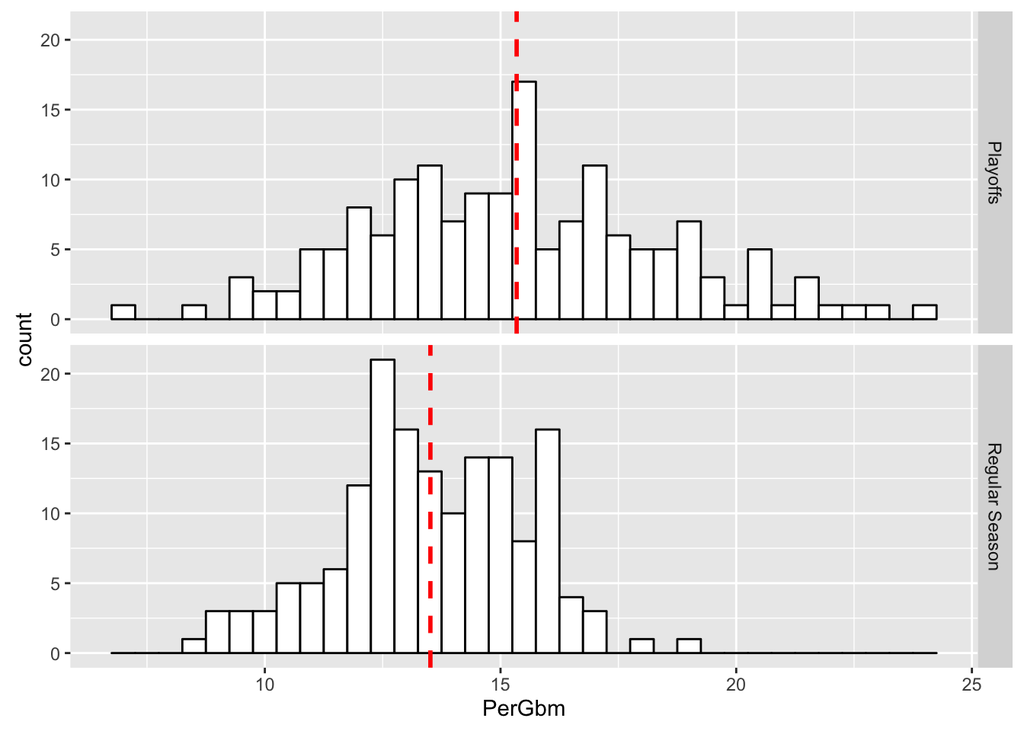

```r
ggplot(dat, aes(x=PerGbm)) + geom_histogram(binwidth=.5, colour="black", fill="white") +
  facet_grid(cond ~ .) +
  geom_vline(data=cdat, aes(xintercept=PerGbm.mean),
             linetype="dashed", size=1, colour="red")
```

# 6 Box plots

## 6.1 A basic box plot

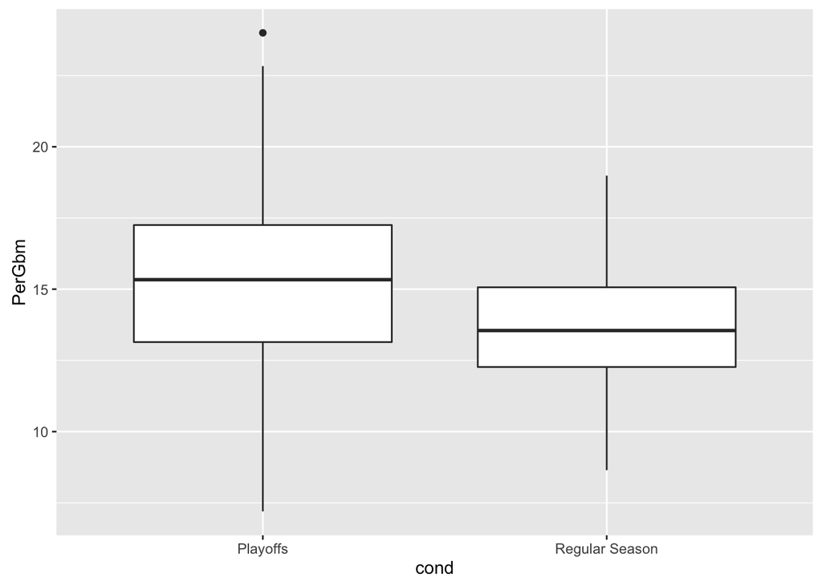

```r
ggplot(dat, aes(x=cond, y=PerGbm)) + geom_boxplot()
```

## 6.2 A basic box with the conditions colored

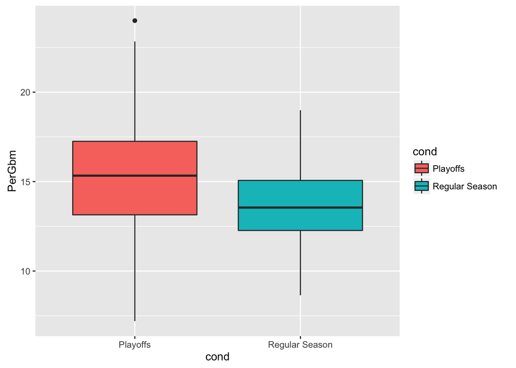

```r
ggplot(dat, aes(x=cond, y=PerGbm, fill=cond)) + geom_boxplot()
```

## 6.3 The above adds a redundant legend. With the legend removed.

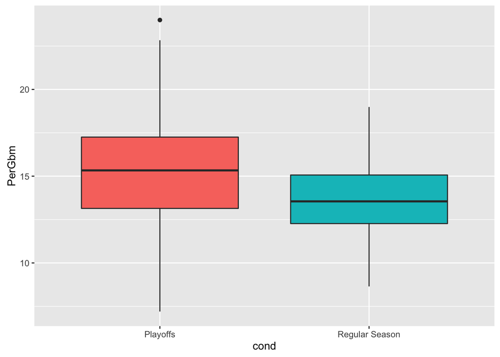

```r
ggplot(dat, aes(x=cond, y=PerGbm, fill=cond)) + geom_boxplot() +
  guides(fill=FALSE)
```

## 6.4 With flipped axes

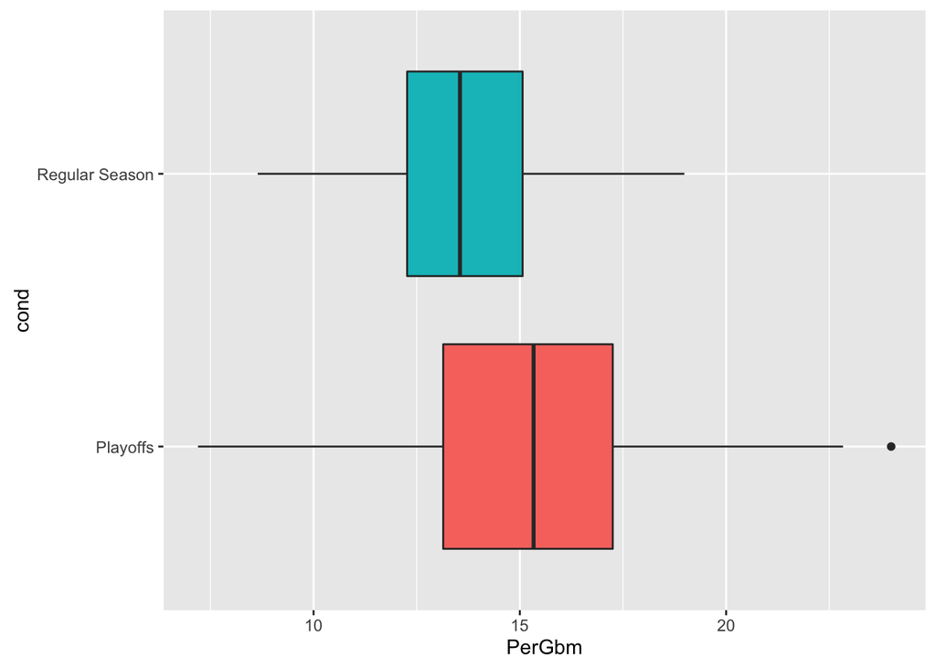

```r
ggplot(dat, aes(x=cond, y=PerGbm, fill=cond)) + geom_boxplot() +
  guides(fill=FALSE) + coord_flip()
```

## 6.5 It’s also possible to add the mean by using stat_summary

Add a diamond at the mean, and make it larger

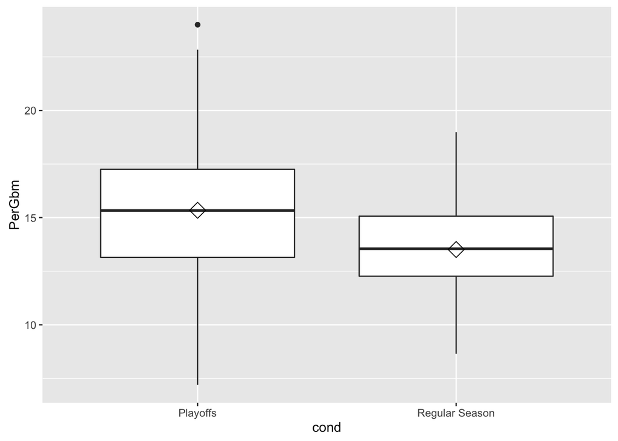

```r
ggplot(dat, aes(x=cond, y=PerGbm)) + geom_boxplot() +
  stat_summary(fun.y=mean, geom="point", shape=5, size=4)
```

# 7 Does shot blocking look like it changes over the course of the last decade?

## 7.1 Build combined data

```r
dat <- df %>%
  group_by(season) %>%
  arrange(season, blkPerGmRegular) %>%
  mutate(cond = as.character(season))
```

## 7.2 Box plots

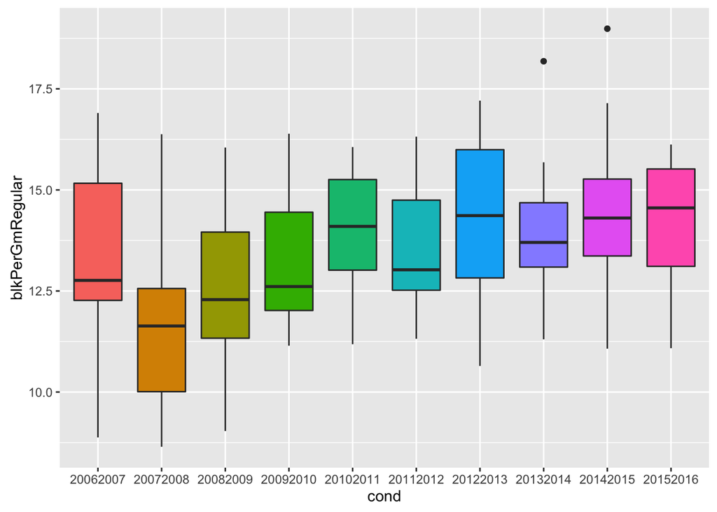

```r
ggplot(dat, aes(x=cond, y=blkPerGmRegular, fill=cond)) +
  geom_boxplot() + guides(fill=FALSE)
```